# mwmap: A Complete Guide to Mapping Malawi in R

Creating Publication-Ready Maps with Administrative Boundary Data

Author

Chifundo Bita

Published

April 10, 2026

# Introduction

**mwmap** is an R package that makes it easy to create accurate, professional maps of Malawi using nothing more than a few lines of R code. It bundles pre-processed spatial boundary data for every administrative level in the country — from the national border down to individual Traditional Authorities — and wraps that data in a family of functions that handle the tedious parts of GIS work for you: joining your spreadsheet data to map geometries, normalising inconsistent district name spellings, choosing colour scales, and producing figures that are ready to drop straight into a report or publication.

The package is built on top of **ggplot2** and **sf**, the two most widely used R packages for data visualisation and spatial analysis respectively. If you already know ggplot2, you will feel immediately at home — every mwmap function returns a ggplot2 object, so you can add layers, themes, and scales using the familiar `+` operator.

You do not need to be a GIS expert to use mwmap. You do not need to download shapefiles, reproject coordinate systems, or understand spatial data formats. All of that is handled internally. What you bring is your district-level data — disease counts, survey estimates, economic indicators — and mwmap handles the cartographic heavy lifting.

**NoteInstallation**

**mwmap** is available on CRAN and can be installed in the usual way:

```r
# Stable release from CRAN
install.packages("mwmap")

# Latest development version from GitHub
# install.packages("remotes")
remotes::install_github("bitacanalytics/mwmap")
```

Once installed, load it alongside ggplot2:

```r
library(mwmap)
library(ggplot2)
```

## 0.1 What is in the package?

mwmap is organised into five functional groups. Understanding this structure helps you find the right function quickly.

**Core mapping functions** produce the base map canvas. You will almost always start with one of these before adding any data layers on top.

**Data and joining functions** are the bridge between your spreadsheet and the map geometry. They handle the spatial join, clean up district names, and report on how well your data matched the shapefile.

**Layer functions** add elements on top of an existing base map — highlighted districts, point locations, text labels. These are designed to be chained together using `+`.

**Styling functions** control colour scales and overall layout. The built-in palettes have been chosen to work well for the most common Malawi mapping use cases (health, agriculture, poverty, administration).

**Utility functions** are helpers you will use indirectly but that are also useful on their own — particularly for cleaning district name columns before a join.

mwmap function groups

| Category | Functions |
| --- | --- |
| **Core mapping** | `mw_map()`, `mw_regions()`, `mw_ta_map()` |
| **Data & joining** | `mw_join()`, `mw_choropleth()`, `mw_districts()`, `mw_districts_simple()` |
| **Map layers** | `mw_highlight()`, `mw_highlight_multi()`, `mw_points()`, `mw_labels()`, `mw_label_repel()` |
| **Styling** | `mw_layout()`, `scale_fill_mw()`, `get_mw_palette()`, `get_mw_palettes()`, `view_mw_palettes()` |
| **Utilities** | `mw_clean_names()`, `mw_suggest_matches()` |

The package also ships five **built-in spatial datasets**. These are `sf` objects — essentially data frames where one column contains polygon geometry — sourced from the Malawi Spatial Data Platform (MASDAP) and pre-processed for use in R.

Spatial datasets bundled in mwmap

| Dataset | Description | Polygons |
| --- | --- | --- |
| `mw_level_0` | National boundary of Malawi | 1 |
| `mw_level_1` | The three administrative regions | 3 |
| `mw_level_2` | All 28 districts | 28 |
| `mw_level_3` | Traditional Authorities (sub-district) | ~250 |
| `major_lakes` | Lake Malawi, Lake Malombe, Lake Chilwa | 3 |

You can use these datasets directly in your own `sf` or `ggplot2` code, but in most cases the mwmap functions will load them automatically for you.

# 1 Getting Started

## 1.1 Your first map

The fastest way to get started is to call `mw_map()` with no arguments. This produces a clean, grey district-level outline of Malawi in a single line of code.

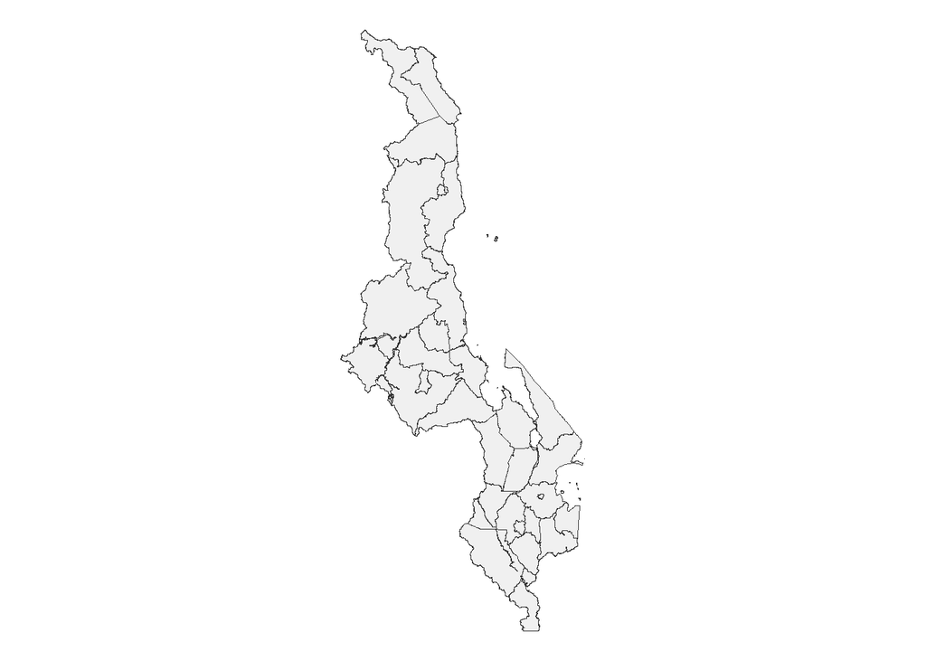

Figure 1: A minimal Malawi map produced by mw_map() with no arguments.

```r
library(mwmap)
library(ggplot2)

mw_map()
```

What you get back is a standard **ggplot2 object** — the same kind of object you get from calling `ggplot()`. This is important because it means you can immediately extend the map using any ggplot2 syntax you already know. Want to add a title? Use `labs()`. Want to change the background colour? Use `theme()`. Want to add a second layer of points or polygons? Just use `+`.

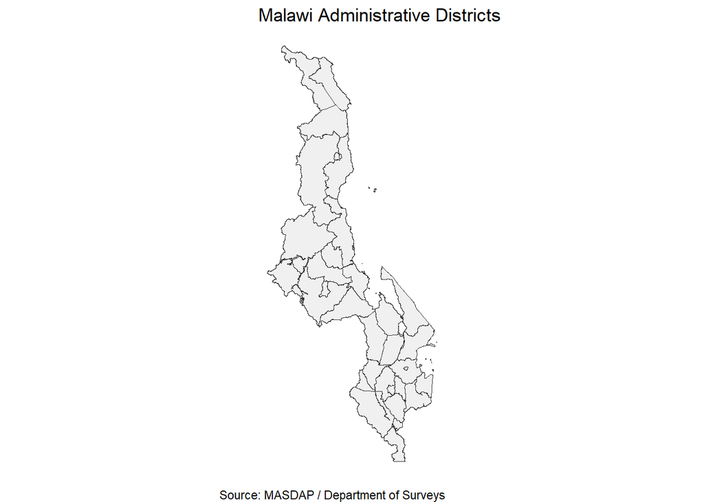

Figure 2: The same map with a title and caption added using standard ggplot2 labs().

```r
mw_map() +
  labs(
    title = "Malawi Administrative Districts",
    caption = "Source: MASDAP / Department of Surveys"
  )
```

## 1.2 Understanding administrative levels

Malawi’s administrative geography has four nested levels. mwmap bundles data for all four, and you switch between them using the `level` argument in `mw_map()`.

- **Level 0** is the national boundary — useful as a reference outline or backdrop behind other data.
- **Level 1** shows the three regions: Northern, Central, and Southern. Regional comparisons — vaccination coverage, food security — are a natural fit for this level.
- **Level 2** is the default and the most commonly used level. Malawi’s 28 districts are the primary unit for government statistics, health surveillance, and most national surveys.
- **Level 3** shows Traditional Authorities, the sub-district units governed by traditional leaders. This is the finest grain available in the package and is useful for local-level planning and community health work.

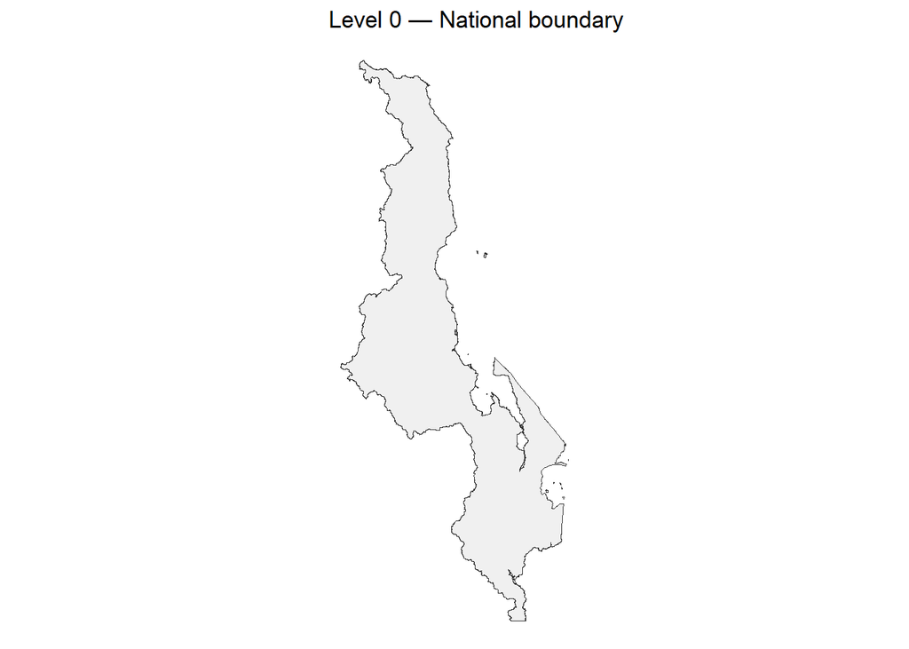

Figure 3: All four administrative levels available in mwmap. Level 2 (districts) is the default.

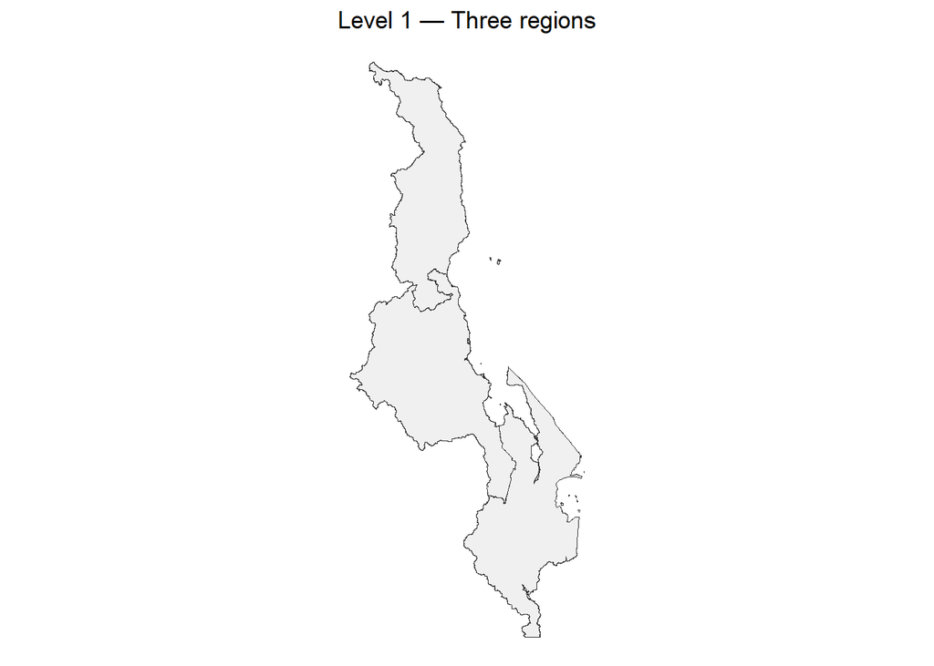

Figure 4: All four administrative levels available in mwmap. Level 2 (districts) is the default.

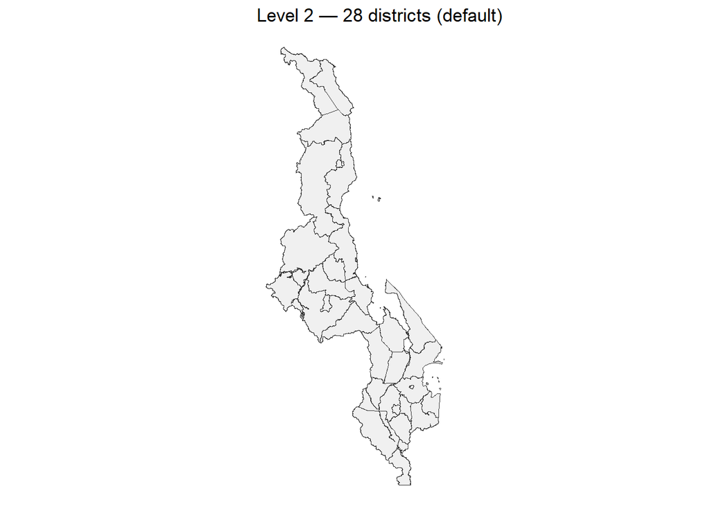

Figure 5: All four administrative levels available in mwmap. Level 2 (districts) is the default.

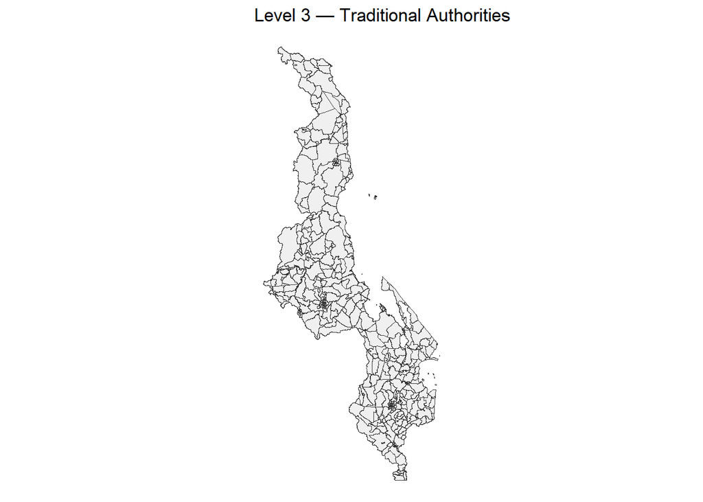

Figure 6: All four administrative levels available in mwmap. Level 2 (districts) is the default.

```r
mw_map(level = 0) + labs(title = "Level 0 — National boundary")
mw_map(level = 1) + labs(title = "Level 1 — Three regions")
mw_map(level = 2) + labs(title = "Level 2 — 28 districts (default)")
mw_map(level = 3) + labs(title = "Level 3 — Traditional Authorities")
```

Notice how level 3 is considerably more detailed. Because Traditional Authority boundaries are complex, rendering the full level-3 map is slower than the other levels. If you only need a subset of TAs — for example, those in a single district — use `mw_ta_map(districts = "Lilongwe")` rather than `mw_map(level = 3)` to keep rendering fast.

## 1.3 Filtering to a region or set of districts

You will often want to focus on a subset of the country rather than mapping everything at once. mwmap gives you two built-in filters:

- `region` accepts the full region name (`"Northern"`, `"Central"`, `"Southern"`) or a single-letter shortcut (`"n"`, `"c"`, `"s"`).
- `districts` accepts a character vector of district names. Matching is case-insensitive.

When you filter to a region, `mw_map()` automatically crops the bounding box so the selected area fills the plot. You do not need to adjust any axis limits manually.

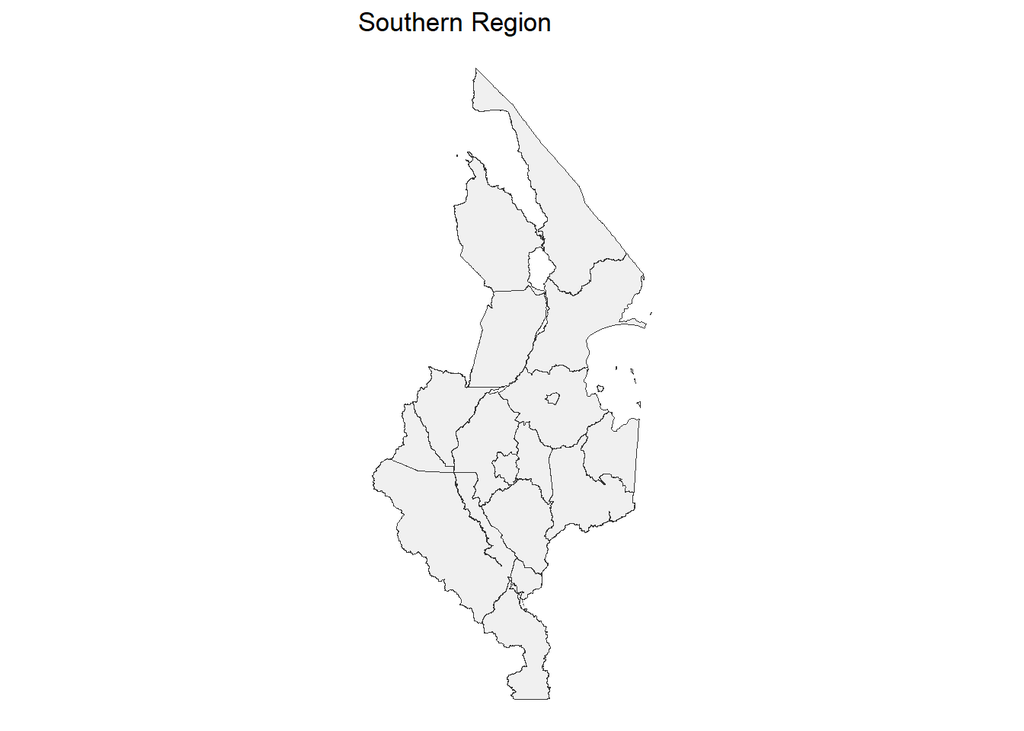

Figure 7: Filtering to a single region (left) or a custom set of districts (right).

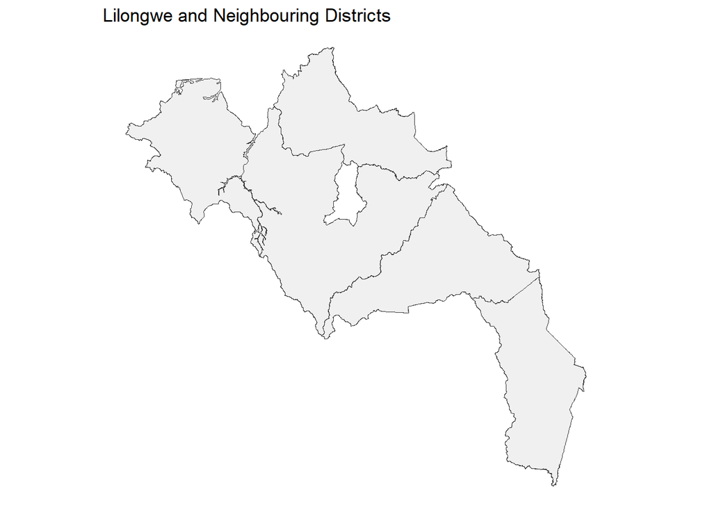

Figure 8: Filtering to a single region (left) or a custom set of districts (right).

```r
# Shortcut "s" is equivalent to "Southern"
mw_map(region = "s") +
  labs(title = "Southern Region")

# Show Lilongwe and its neighbouring districts
mw_map(districts = c("Lilongwe", "Dowa", "Dedza", "Ntcheu", "Mchinji")) +
  labs(title = "Lilongwe and Neighbouring Districts")
```

# 2 The Core Mapping Functions

## 2.1 `mw_map()` — the main workhorse

`mw_map()` is the central function in the package. Nearly every workflow starts here. It is designed to be useful at both extremes — a single call with no arguments produces a clean outline, while a heavily parameterised call can produce a complete choropleth with highlights, labels, and lake overlay in one step.

The table below covers the most important arguments. A complete reference is available via `?mw_map`.

Key `mw_map()` arguments

| Argument | Default | What it does |
| --- | --- | --- |
| `level` | `2` | Administrative level: 0 = country, 1 = regions, 2 = districts, 3 = TAs |
| `data` | `NULL` | A data frame or sf object with values to display |
| `fill` | `NULL` | Column name (as a string) to use for choropleth fill colour |
| `fill_color` | `"#f0f0f0"` | Solid fill colour when no `fill` column is provided |
| `lakes` | `FALSE` | Whether to overlay the three major lakes |
| `lake_color` | `"#9ecae1"` | Fill colour for lakes |
| `borders` | `TRUE` | Whether to draw polygon borders |
| `border_color` | `"#333333"` | Border colour |
| `border_size` | `0.3` | Border line width |
| `region` | `NULL` | Restrict map to one region |
| `districts` | `NULL` | Restrict map to named districts |
| `label_districts` | `FALSE` | Add district name labels at centroids |
| `label_size` | `3` | Size of district labels |
| `highlight_districts` | `NULL` | Districts to draw with a bold coloured border |
| `highlight_border_color` | `"#E41A1C"` | Colour of the highlight border |
| `highlight_fill` | `NA` | Fill colour for highlighted districts (NA = transparent) |
| `interactive` | `FALSE` | Return a plotly interactive map instead of ggplot2 |
| `title`, `subtitle`, `caption` | `NULL` | Map text elements |

### 2.1.1 Adding the major lakes

Malawi is defined by water as much as by its land. Lake Malawi covers roughly a fifth of the country’s total area, and Lakes Malombe and Chilwa are significant features in the south. For most maps, adding the lakes makes the geography immediately recognisable to a Malawian audience and gives the reader an important spatial reference point.

Set `lakes = TRUE` to overlay them. You can adjust the fill colour with `lake_color` and the border with `lake_border_color`.

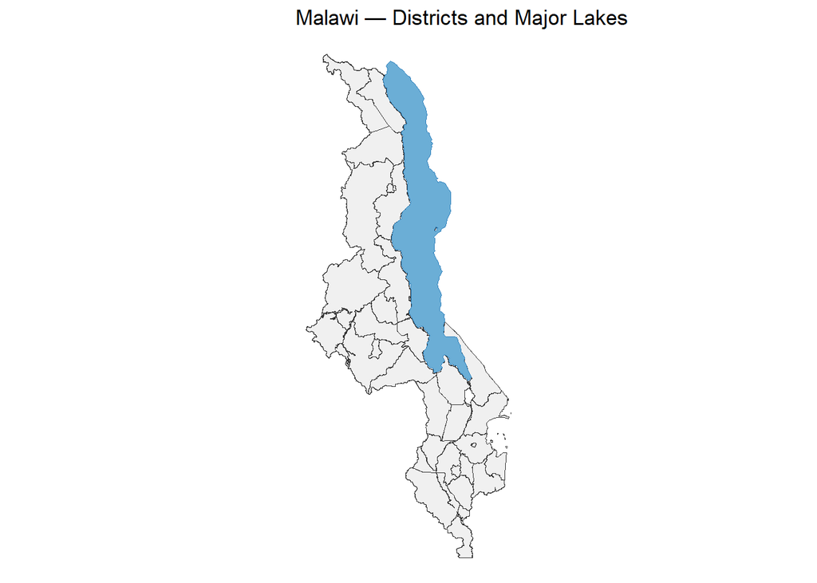

Figure 9: District map with major lakes overlaid. The lakes are stored as a separate sf dataset (major_lakes) and drawn on top of the district polygons.

```r
mw_map(
  lakes = TRUE,
  lake_color = "#6BAED6",
  lake_border_color = "#3182BD"
) +
  labs(title = "Malawi — Districts and Major Lakes")
```

### 2.1.2 Highlighting specific districts

`mw_map()` has built-in support for drawing attention to specific districts without needing a separate `mw_highlight()` layer. Use `highlight_districts` to name the districts you want to emphasise.

By default, the highlight draws a bold red border around the named districts. You can customise the border colour, border width, and fill colour. Setting `highlight_fill = NA` (the default) makes the fill transparent — only the bold border draws attention while the underlying fill colour remains visible.

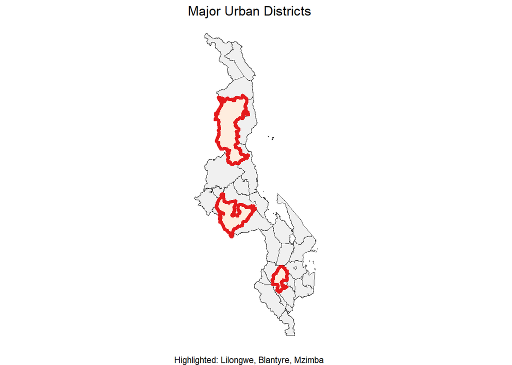

Figure 10: Three major urban districts highlighted with a bold coloured border and a light orange fill.

```r
mw_map(
  highlight_districts = c("Lilongwe", "Blantyre", "Mzimba"),
  highlight_border_color = "#E41A1C",
  highlight_border_size = 1.5,
  highlight_fill = "#FEEDDE"
) +
  labs(
    title = "Major Urban Districts",
    caption = "Highlighted: Lilongwe, Blantyre, Mzimba"
  )
```

### 2.1.3 Adding district name labels

Set `label_districts = TRUE` to add each district name at the centroid of its polygon. Labels that would overlap are automatically suppressed. For finer control — labelling only specific districts, changing the font, or using ggrepel for non-overlapping placement — use the standalone `mw_labels()` function described in Section 4.4.

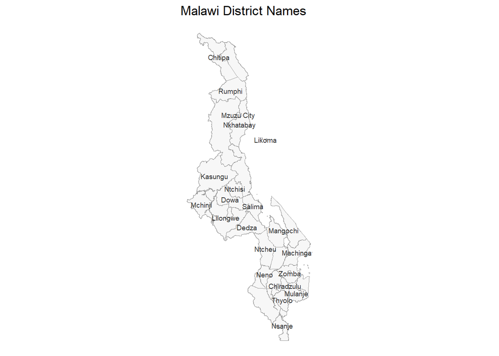

```r
mw_map(
  fill_color = "#f7f7f7",
  border_color = "grey60",
  label_districts = TRUE,
  label_size = 2.5,
  label_color = "#333333"
) +
  labs(title = "Malawi District Names")
```

## 2.2 `mw_regions()` — regional overview

`mw_regions()` is a convenience function that aggregates the 28 district polygons into the three administrative regions and plots them. Internally it calls `dplyr::group_by()` and `sf::st_union()` to dissolve district boundaries, so you do not need to pre-process the data yourself.

Use this function when your analysis is at the regional level — comparing Northern, Central, and Southern on some indicator — or when you need a clean regional overview to orient the reader at the start of a report.

The `region_colors` argument accepts a named vector where the names are `"Northern"`, `"Central"`, and `"Southern"`. This makes it straightforward to encode data values as fill colours by pre-computing the colour for each region and passing the result in.

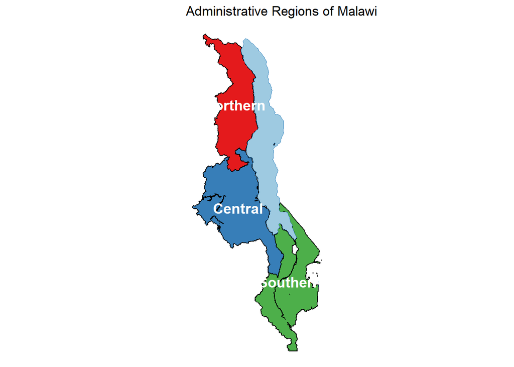

Figure 12: The three administrative regions with distinct colours, name labels, and the major lakes overlaid.

```r
mw_regions(
  region_colors = c(
    "Northern" = "#E41A1C",
    "Central" = "#377EB8",
    "Southern" = "#4DAF4A"
  ),
  labels = TRUE,
  label_size = 5,
  label_color = "white",
  label_face = "bold",
  lakes = TRUE
) +
  labs(title = "Administrative Regions of Malawi")
```

Notice that `labels = TRUE` places each region name at the geometric centroid of the dissolved polygon. For the Southern Region — which wraps around Lake Malawi — the centroid may not look perfectly centred visually, but it is the mathematical centre of the polygon.

## 2.3 `mw_ta_map()` — traditional authorities

Traditional Authorities (TAs) are the sub-district administrative units in Malawi, each governed by a customary chief. The package includes boundaries for approximately 250 TAs sourced from MASDAP. `mw_ta_map()` is a dedicated function for rendering these boundaries, with several features designed for working at this fine scale.

The most important argument is `districts`. Rendering all 250 TAs at once is slow and the resulting map is very dense. It is almost always better to filter to the district or districts you care about. When you do, `mw_ta_map()` also draws the district boundary on top of the TA polygons by default (`district_border = TRUE`), which helps the reader understand where the selected TAs sit within the broader geography.

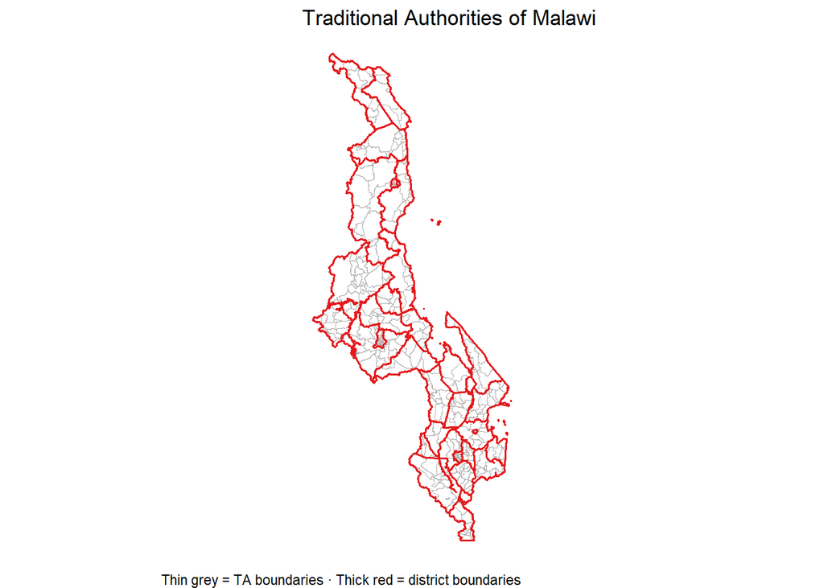

Figure 13: All Traditional Authorities. Thin grey lines are TA boundaries; thicker red lines are district boundaries drawn on top.

```r
mw_ta_map(
  border_color = "grey70",
  border_size = 0.15,
  district_border = TRUE,
  district_border_color = "#E41A1C",
  district_border_size = 0.6
) +
  labs(
    title = "Traditional Authorities of Malawi",
    caption = "Thin grey = TA boundaries · Thick red = district boundaries"
  )
```

Filtering to specific districts dramatically improves readability and speed.

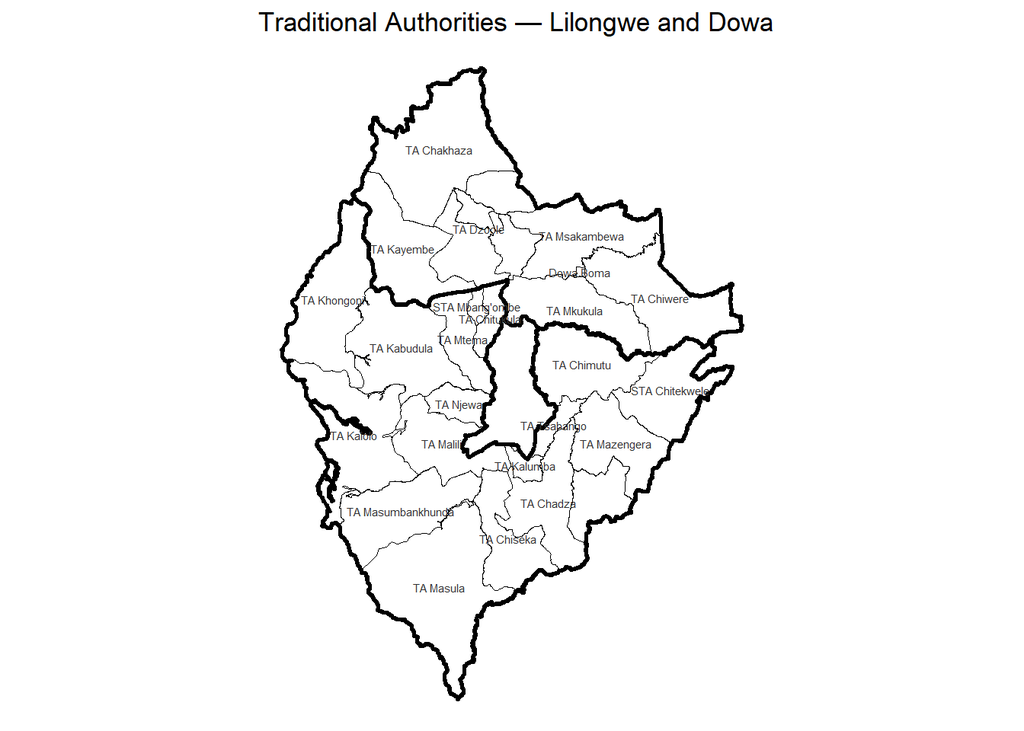

Figure 14: TAs in just two districts. Filtering with the districts argument makes the map much more readable and faster to render.

```r
mw_ta_map(
  districts = c("Lilongwe", "Dowa"),
  labels = TRUE,
  label_size = 2,
  label_color = "#333333",
  district_border_color = "black",
  district_border_size = 0.9
) +
  labs(title = "Traditional Authorities — Lilongwe and Dowa")
```

**Tip`mw_ta_map()` vs `mw_map(level = 3)`**

Both produce TA-level maps but are designed for different situations. Use `mw_map(level = 3)` when you want to layer TA boundaries on top of other `mw_map()` features like fill data, highlights, or points. Use `mw_ta_map()` when you want the dedicated district-border overlay and the `districts` filter, which are specific to this function.

# 3 Choropleth Mapping

A choropleth map uses colour to encode a quantitative or categorical variable, with each polygon coloured according to its value. This is by far the most common type of thematic map in research and reporting — malaria incidence by district, poverty rates by region, vaccination coverage by TA.

mwmap gives you two workflows for choropleth mapping: a **quick one-step route** via `mw_choropleth()`, and a **flexible two-step route** via `mw_join()` + `mw_map()`. Both produce the same kind of output; the choice depends on how much control you need over the final appearance.

## 3.1 Quick route — `mw_choropleth()`

`mw_choropleth()` is designed for speed. You pass it a data frame, the name of the column you want to map (unquoted, like a tidyverse verb), and optionally a palette name. It handles the join, the scale, and the plot in a single call.

The key arguments are:

- `data` — your data frame. It must contain a column of district names.
- `value` — the column to map, passed **unquoted** (e.g. `malaria_cases`, not `"malaria_cases"`).
- `district_col` — the name of the district name column in your data. Defaults to `"district"`.
- `palette` — one of the 25 named mwmap palettes. Defaults to `"health"`.
- `scale_type` — `"auto"` (the default) detects whether your variable is numeric (continuous scale) or a factor (discrete scale).
- `lakes` — whether to overlay major lakes.
- `title`, `subtitle`, `caption` — text elements for the map.

To demonstrate, we will use a simulated dataset of malaria indicators for all 28 districts. This same dataset is reused throughout the rest of this guide.

```r
# Reading simulated district-level health data for all 28 districts

health_data <- read_csv("Malaria_data.csv")

head(health_data)
```

| district | malaria_cases | population |
| --- | --- | --- |
| Lilongwe | 12450 | 2300000 |
| Blantyre | 9870 | 1800000 |
| Mzimba | 6540 | 940000 |
| Zomba | 7820 | 1050000 |
| Mzuzu City | 2310 | 220000 |
| Kasungu | 4560 | 780000 |

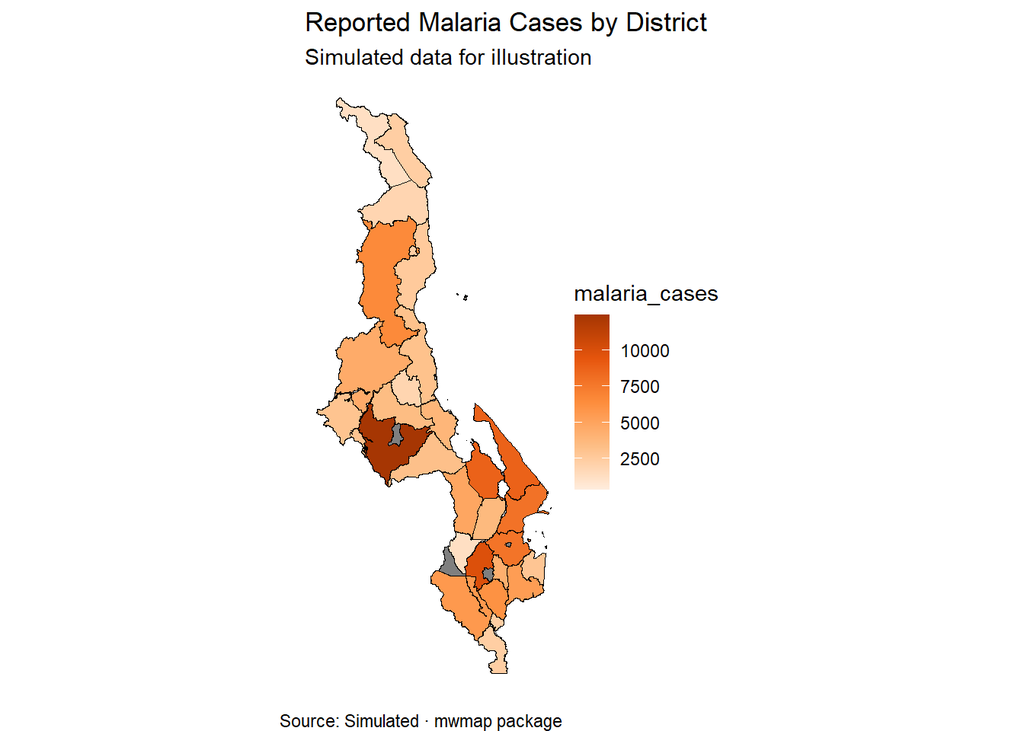

Figure 15: A basic choropleth of malaria case counts. Note how Lilongwe and Blantyre dominate simply because they have the largest populations — not necessarily the highest risk.

```r
mw_choropleth(
  health_data,
  malaria_cases,
  palette = "malaria",
  title = "Reported Malaria Cases by District",
  subtitle = "Simulated data for illustration",
  caption = "Source: Simulated · mwmap package"
)
```

### 3.1.1 Why you should map rates, not raw counts

The map above shows Lilongwe and Blantyre with the highest case counts. But those are also Malawi’s two most populous districts — of course they have more cases. This is a classic pitfall in choropleth mapping. A map of raw counts often tells you more about population distribution than about the phenomenon you are trying to understand.

The solution is to compute a **rate** — dividing the count by the population to put all districts on a comparable footing. A rate per 1,000 population is a standard epidemiological measure.

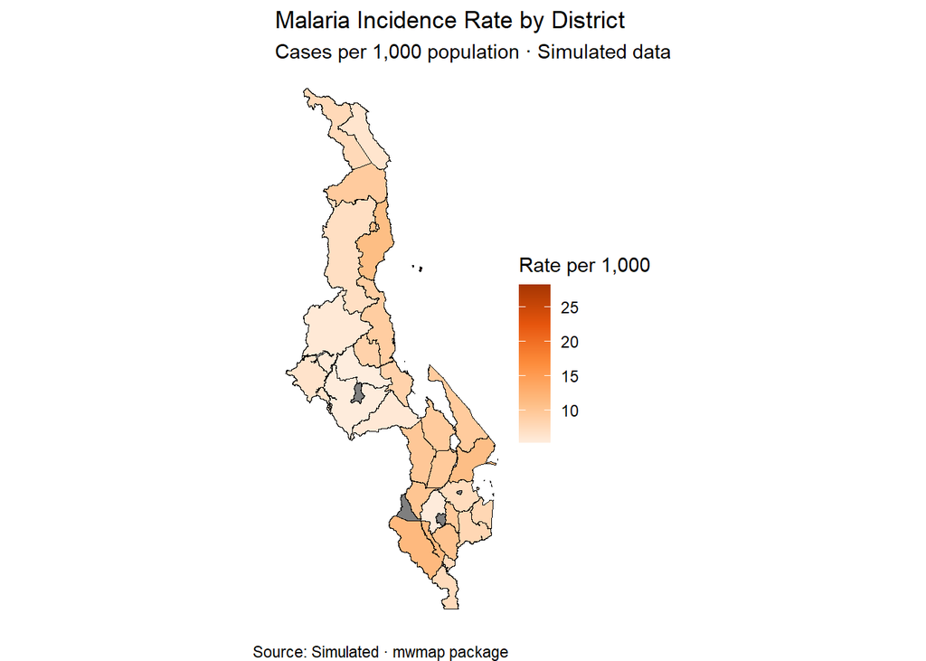

Figure 16: The same data expressed as a rate per 1,000 population. The geographic pattern is now very different — smaller, more rural districts may show higher burden than the urban centres.

```r
health_data$rate_per_1000 <- round(
  health_data$malaria_cases / health_data$population * 1000,
  1
)

mw_choropleth(
  health_data,
  rate_per_1000,
  palette = "malaria",
  title = "Malaria Incidence Rate by District",
  subtitle = "Cases per 1,000 population · Simulated data",
  legend_title = "Rate per 1,000",
  caption = "Source: Simulated · mwmap package",
  n_breaks = 5
)
```

Comparing these two maps is instructive. The count map is dominated by the two big cities; the rate map may look completely different, revealing high-burden districts that were invisible in the count map.

### 3.1.2 Categorical (discrete) choropleths

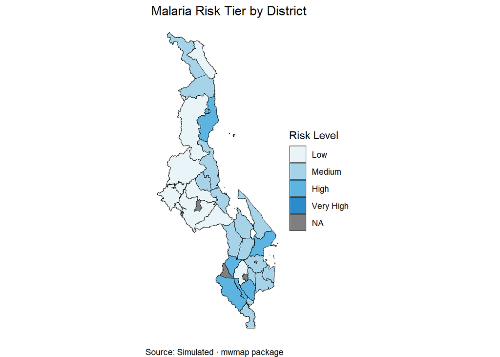

Figure 17: A categorical choropleth. mw_choropleth() detects the factor variable automatically and uses a discrete scale.

```r
health_data$risk_tier <- cut(
  health_data$rate_per_1000,
  breaks = c(0, 4, 7, 10, 15, Inf),
  labels = c("Very Low", "Low", "Medium", "High", "Very High"),
  right = TRUE
)

mw_choropleth(
  health_data,
  risk_tier,
  palette = "health",
  title = "Malaria Risk Tier by District",
  legend_title = "Risk Level",
  caption = "Source: Simulated · mwmap package"
)
```

## 3.2 Flexible route — `mw_join()` + `mw_map()`

When you need more control than `mw_choropleth()` offers — a custom scale, additional layers, multiple fills — the two-step approach gives you full flexibility. The idea is simple:

1. **Join** your data to the map geometry using `mw_join()`, producing an `sf` object where every district row is enriched with your data columns.
2. **Plot** that joined `sf` object using `mw_map(data = ..., fill = ...)`.

Because the result of step 1 is an `sf` object, you can then add any ggplot2 scales, `mw_highlight()` layers, `mw_points()` layers, or custom themes.

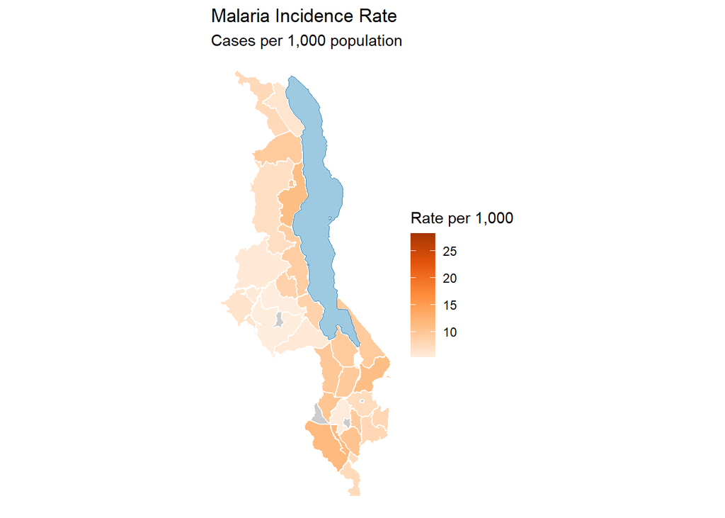

Figure 18: The two-step mw_join() + mw_map() workflow. Joining first gives you full control over scales and additional layers.

```r
# Step 1: join your data frame to the district polygons
joined <- mw_join(
  data = health_data,
  district_col = "district",
  quiet = TRUE
)

# Step 2: pass the joined sf object to mw_map()
mw_map(
  data = joined,
  fill = "rate_per_1000",
  lakes = TRUE,
  border_color = "white",
  border_size = 0.4,
  title = "Malaria Incidence Rate",
  subtitle = "Cases per 1,000 population"
) +
  scale_fill_mw(
    palette = "malaria",
    name = "Rate per 1,000",
    na.value = "grey80"
  )
```

### 3.2.1 How `mw_join()` works

`mw_join()` is more than a simple merge. Under the hood it does several things that make it far more robust than calling `dplyr::left_join()` directly:

**Name standardisation.** Before attempting to match, `mw_join()` passes all district names through `mw_clean_names()` automatically. This normalises capitalisation, removes trailing words like “District” or “TA”, and fixes known variants (for example, “Nkhata Bay” becomes “Nkhatabay” to match the shapefile). Most of the time your data will join cleanly without any pre-processing.

**A matching report.** By default (`verbose = TRUE`), `mw_join()` prints a summary showing how many of your districts matched the shapefile, which ones did not match, and — for the unmatched ones — a list of suggested alternatives based on string similarity. This is invaluable for catching typos early.

**A left join by default.** `mw_join()` keeps all 28 district rows from the shapefile regardless of whether your data has a value for that district (`keep_all = TRUE`). Districts with no data appear grey on the map. This prevents the common mistake of accidentally hiding districts with missing data.

```r
# Run mw_join() without quiet = TRUE to see the matching report.
# This is especially useful when working with a new dataset for the first time.
joined_verbose <- mw_join(
  data.frame(
    district = c("lilongwe", "BLANTYRE", "Mzimba", "Zomba City"),
    value = c(120, 200, 85, 60)
  ),
  district_col = "district"
)
# mw_join() will tell you that "Zomba City" did not match and suggest "Zomba"
```

# 4 Adding Map Layers

One of the strengths of the mwmap + ggplot2 approach is that maps are **composable**. You build a base map and then stack layers on top using `+`. This section covers the main layer functions.

## 4.1 `mw_highlight()` — draw attention to districts

`mw_highlight()` overlays a coloured fill or bold outline on specific districts. It is useful whenever you want to direct the reader’s eye to particular areas — the districts covered by a programme, the ones that exceed a threshold, the capital and major cities.

The key arguments are:

- `districts` — district names to highlight (case-insensitive).
- `fill` — the fill colour. Defaults to `"red"`.
- `color` — the border colour. Defaults to `"black"`.
- `alpha` — fill transparency, from 0 (invisible) to 1 (opaque).
- `size` — border line width.
- `outline_only` — if `TRUE`, suppresses the fill and draws only the border. Ideal for adding emphasis on top of a choropleth without obscuring data values.
- `label` — if `TRUE`, adds district name labels inside highlighted areas.

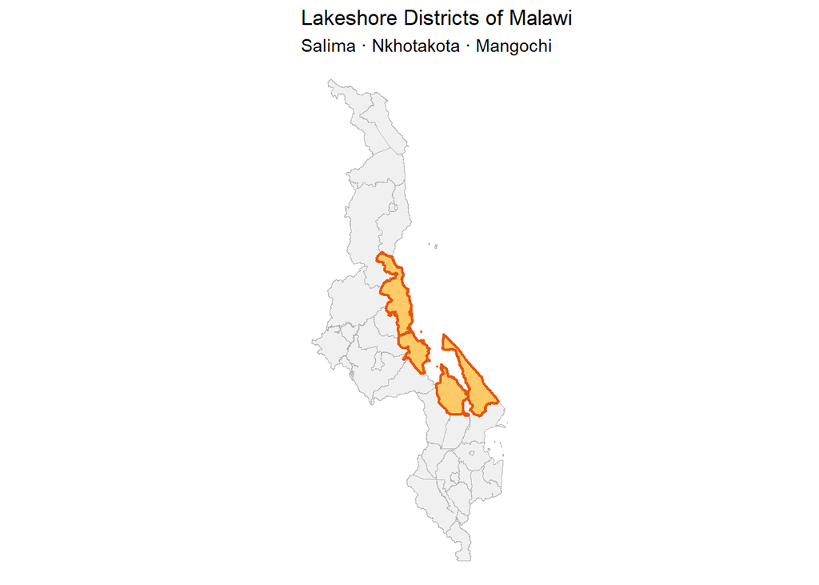

Figure 19: Three lakeshore districts highlighted with a gold fill. The highlight layer sits on top of the base map and is styled independently.

```r
mw_map(fill_color = "#f0f0f0", border_color = "grey70") +
  mw_highlight(
    districts = c("Salima", "Nkhotakota", "Mangochi"),
    fill = "#FEC44F",
    color = "#E6550D",
    alpha = 0.85,
    size = 0.8
  ) +
  labs(
    title = "Lakeshore Districts of Malawi",
    subtitle = "Salima · Nkhotakota · Mangochi"
  )
```

### 4.1.1 Using `outline_only = TRUE` on a choropleth

When you have a choropleth showing continuous values, a solid fill highlight would cover the data. The `outline_only` option draws just the border, adding visual emphasis without obscuring the underlying colours.

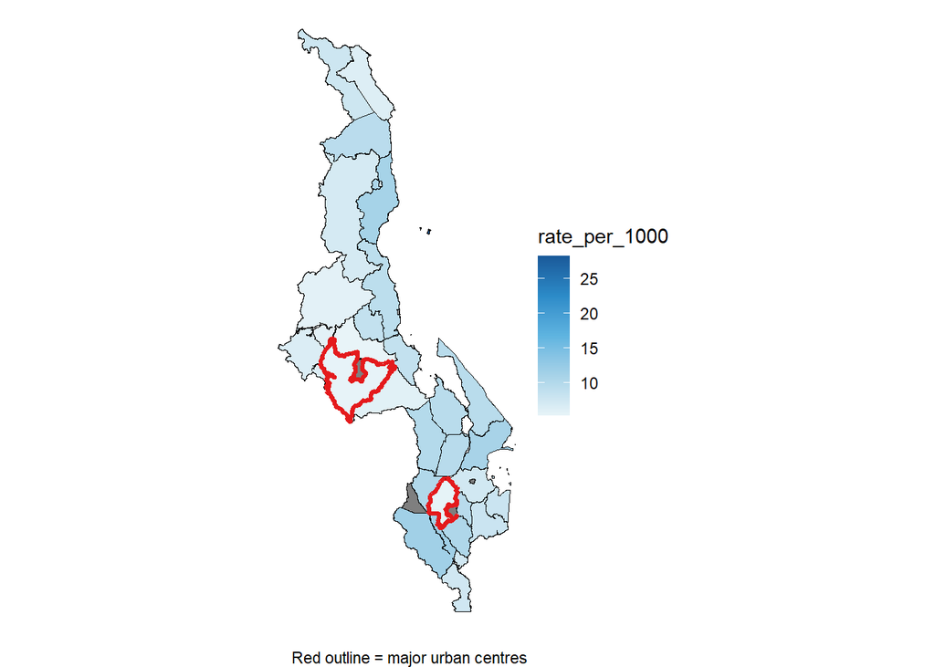

Figure 20: A bold outline highlight layered on top of a choropleth. The fill values remain fully visible.

```r
mw_choropleth(health_data, rate_per_1000, palette = "health", quiet = TRUE) +
  mw_highlight(
    districts = c("Lilongwe", "Blantyre"),
    outline_only = TRUE,
    color = "#E41A1C",
    size = 1.2
  ) +
  labs(caption = "Red outline = major urban centres")
```

## 4.2 `mw_highlight_multi()` — a different colour per district

When you want to highlight several districts but give each one a distinct colour — to show which programme operates in each area, or to indicate different intervention types — `mw_highlight_multi()` accepts a **named vector** where the names are district names and the values are colours.

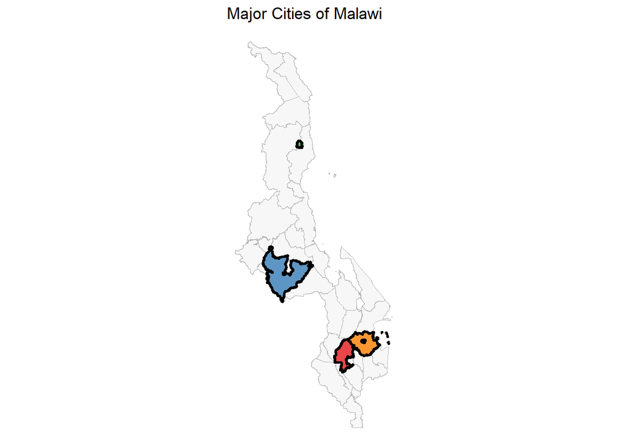

Figure 21: Each highlighted district has its own colour, defined by a named character vector.

```r
mw_map(fill_color = "#f7f7f7", border_color = "grey70") +
  mw_highlight_multi(
    c(
      "Lilongwe" = "#377EB8",
      "Blantyre" = "#E41A1C",
      "Mzuzu City" = "#4DAF4A",
      "Zomba" = "#FF7F00"
    ),
    alpha = 0.8
  ) +
  labs(title = "Major Cities of Malawi")
```

## 4.3 `mw_points()` — plot geographic locations

`mw_points()` adds a layer of points to a map from a data frame containing longitude and latitude columns. Common uses include health facility locations, survey cluster coordinates, school or market sites, and infrastructure.

The `lon` and `lat` arguments are passed **unquoted** — like a tidyverse verb. The function converts the data frame to an `sf` object internally and uses `geom_sf()` so the coordinate system integrates correctly with the base map.

Important: when mapping a column to `color` or `size`, pass the **column name as a quoted string** — e.g. `color = "facility_type"`, not `color = facility_type`. This is different from how `mw_choropleth()` works (which uses unquoted names), because `mw_points()` needs to handle both fixed values (e.g. `color = "red"`) and column names in the same argument.

```r
# Sample health facility data
facilities <- data.frame(
  name = c(
    "Kamuzu Central", "Queen Elizabeth Central", "Mzuzu Central","Zomba Central",
    "Dedza District", "Salima District", "Karonga District", "Mangochi District"),
  lon = c(33.780, 35.002, 34.018, 35.320, 34.339, 34.459, 33.930, 35.264),
  lat = c(-13.978, -15.785, -11.462, -15.380, -14.381, -13.782, -9.932, -14.477),
  level = c(
    "Central", "Central", "Central", "Central", "District", "District", "District", "District" ),
  beds = c(1200, 1350, 600, 450, 180, 160, 200, 210)
)
```

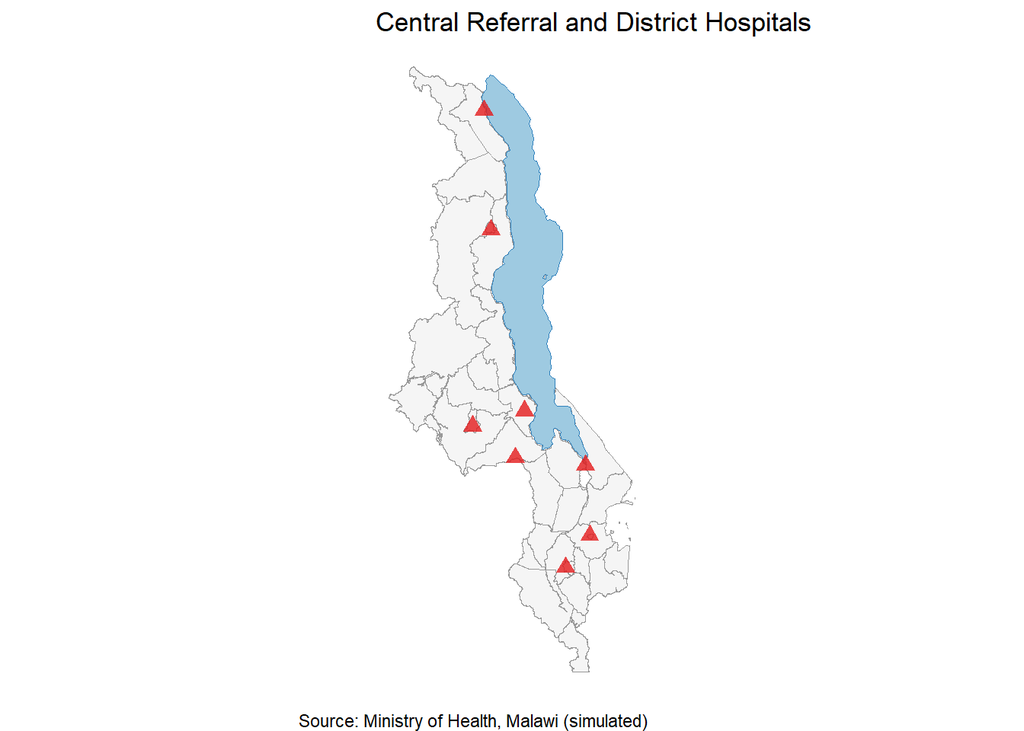

Figure 22: Health facilities plotted as red triangles on a district base map.

```r
mw_map(fill_color = "#f5f5f5", border_color = "grey60", lakes = TRUE) +
  mw_points(
    facilities,
    lon,
    lat,
    color = "#E41A1C",
    size = 3,
    shape = 17 # 17 = filled triangle; 19 = filled circle
  ) +
  labs(
    title = "Central Referral and District Hospitals",
    caption = "Source: Ministry of Health, Malawi (simulated)"
  )
```

### 4.3.1 Mapping point attributes to aesthetics

Pass a **quoted column name** to `color` or `size` to map a data attribute to a visual property. Then add a standard ggplot2 `scale_color_manual()` or `scale_size_continuous()` to control the exact colours and sizes used.

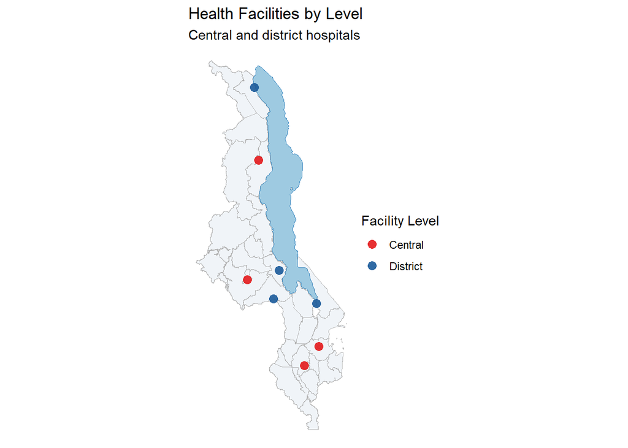

Figure 23: Facility level mapped to point colour. Central hospitals are shown in red, district hospitals in blue.

```r
mw_map(fill_color = "#f0f4f8", border_color = "grey70", lakes = TRUE) +
  mw_points(
    facilities,
    lon,
    lat,
    color = "level", # quoted column name
    size = 3,
    alpha = 0.9
  ) +
  scale_color_manual(
    values = c("Central" = "#E41A1C", "District" = "#1a5a9a"),
    name = "Facility Level"
  ) +
  labs(
    title = "Health Facilities by Level",
    subtitle = "Central and district hospitals"
  )
```

### 4.3.2 Labelling points

Set `label = TRUE` and provide the column name as a string to `label_column` to add text labels next to each point. Labels are automatically suppressed when they would overlap. For repelled, non-overlapping labels, use `repel_labels = TRUE` (requires the `ggrepel` package).

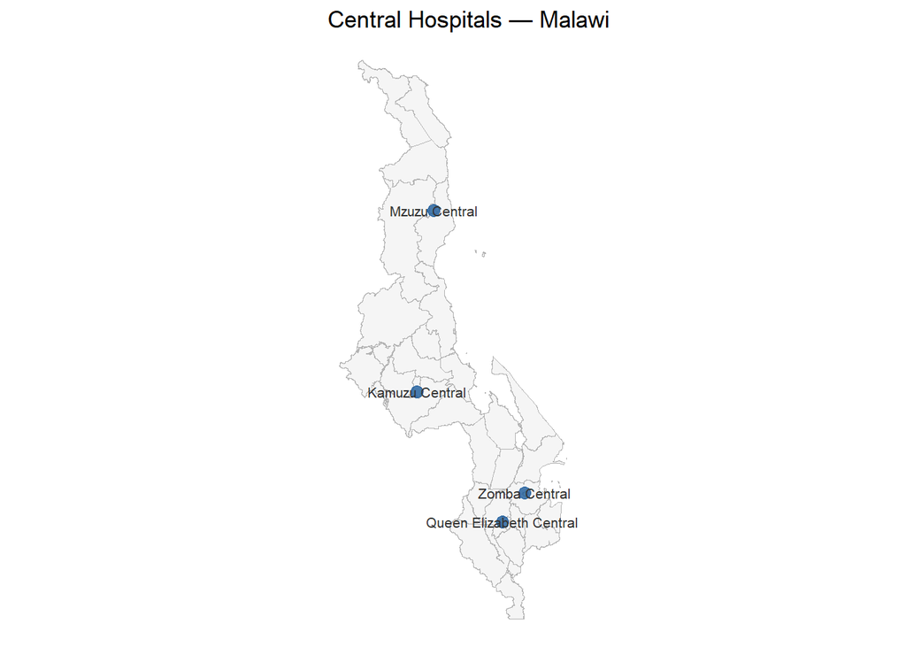

Figure 24: Central hospitals with name labels attached at point coordinates.

```r
hospitals <- facilities[facilities$level == "Central", ]

mw_map(fill_color = "#f5f5f5", border_color = "grey70") +
  mw_points(
    hospitals,
    lon,
    lat,
    color = "#1a5a9a",
    size = 3,
    label = TRUE,
    label_column = "name", # column name as a quoted string
    label_size = 2.8,
    label_color = "#333333"
  ) +
  labs(title = "Central Hospitals — Malawi")
```

## 4.4 `mw_labels()` — district name labels

`mw_labels()` adds district name text at the centroid of each polygon. It is the standalone version of the `label_districts = TRUE` argument in `mw_map()` and gives you more control: you can restrict labels to a subset of districts, change the font, and pass any additional arguments through to `geom_sf_text()`.

The most useful arguments are:

- `districts` — a character vector of district names to label. If `NULL` (default), all districts are labelled.
- `size` — text size. The default of 3 works well for a full-country map.
- `color` — text colour.
- `fontface` — `"plain"`, `"bold"`, `"italic"`, or `"bold.italic"`.
- `label_column` — column to use for the label text. Defaults to `"ADM2_EN"`.

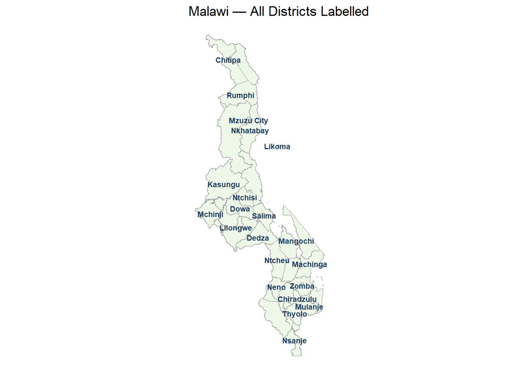

```r
mw_map(fill_color = "#EDF8E9", border_color = "grey60") +
  mw_labels(
    size = 2.5,
    color = "#1a3a5c",
    fontface = "bold"
  ) +
  labs(title = "Malawi — All Districts Labelled")
```

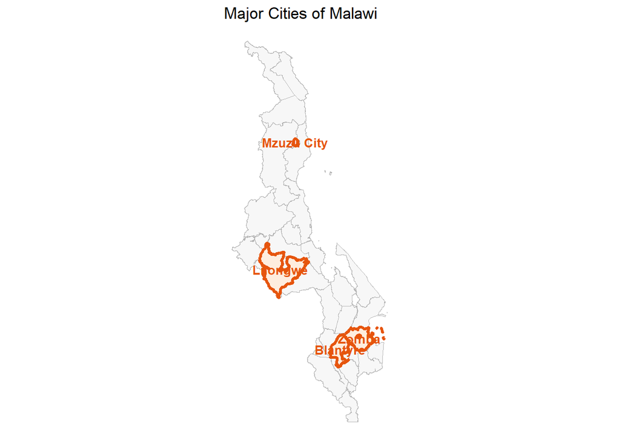

Figure 26: Labels only on the four highlighted cities. Restricting labels to highlighted districts avoids clutter.

```r
mw_map(
  highlight_districts = c("Lilongwe", "Blantyre", "Mzuzu City", "Zomba"),
  highlight_fill = "#FEEDDE",
  highlight_border_color = "#E6550D",
  fill_color = "#f7f7f7",
  border_color = "grey70"
) +
  mw_labels(
    districts = c("Lilongwe", "Blantyre", "Mzuzu City", "Zomba"),
    size = 3.5,
    color = "#E6550D",
    fontface = "bold"
  ) +
  labs(title = "Major Cities of Malawi")
```

# 5 Colour Palettes

Choosing colours for a choropleth map is more than an aesthetic decision. The colours need to encode the magnitude of the variable accurately — readers should be able to intuit that darker means more, or that a colour shift signals a meaningful boundary. The colours also need to work in print, on screen, and for readers with colour-vision deficiencies.

mwmap ships 25 named palettes grouped into seven categories. Each palette is a vector of hex colour codes that has been verified to produce perceptually distinct and readable maps.

## 5.1 Browsing the available palettes

`get_mw_palettes()` returns a data frame of all available palettes with their category, description, and number of colours. This is the quickest way to find the right palette for your subject matter — filter by `category` to narrow the list.

```r
get_mw_palettes()
```

Table 1: All 25 mwmap palettes organised by category.

|  | name | category | description | n_colors |
| --- | --- | --- | --- | --- |
| health | health | health | Health indicators | 5 |
| malaria | malaria | health | Malaria incidence | 5 |
| vaccination | vaccination | health | Vaccination coverage | 5 |
| hiv | hiv | health | HIV prevalence | 7 |
| agriculture | agriculture | agriculture | Agricultural productivity | 5 |
| crops | crops | agriculture | Crop yields | 5 |
| vegetation | vegetation | agriculture | Vegetation indices | 5 |
| rainfall | rainfall | agriculture | Rainfall patterns | 5 |
| poverty | poverty | socioeconomic | Poverty rates | 5 |
| education | education | socioeconomic | Education levels | 5 |
| population | population | socioeconomic | Population density | 5 |
| development | development | socioeconomic | Development indices | 5 |
| admin | admin | administrative | Administrative boundaries | 5 |
| regions | regions | administrative | Regions (3 colors) | 3 |
| districts | districts | administrative | Districts (10 colors) | 10 |
| blues | blues | sequential | Sequential blues | 6 |
| greens | greens | sequential | Sequential greens | 6 |
| oranges | oranges | sequential | Sequential oranges | 5 |
| purples | purples | sequential | Sequential purples | 5 |
| divergence | divergence | diverging | Diverging (blue-red) | 9 |
| temperature | temperature | diverging | Temperature diverging | 11 |
| qualitative_1 | qualitative_1 | qualitative | Qualitative set 1 | 9 |
| qualitative_2 | qualitative_2 | qualitative | Qualitative set 2 | 8 |
| malawi_flag | malawi_flag | administrative | Malawi flag colors | 3 |
| lakes | lakes | sequential | Lake colors | 4 |

`view_mw_palettes()` displays all palettes as colour swatches in a ggplot2 chart, which makes it easy to compare options visually before committing to one.

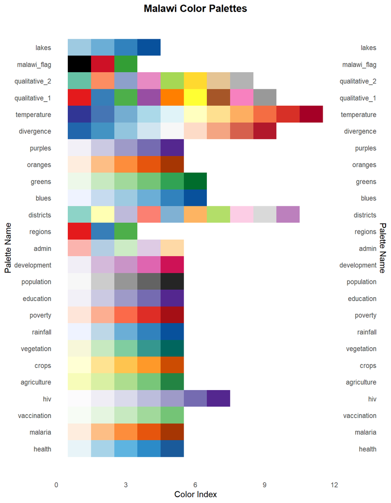

Figure 27: All 25 mwmap palettes as colour swatches.

```r
view_mw_palettes()
```

## 5.2 Using `scale_fill_mw()`

`scale_fill_mw()` is a ggplot2 scale function — drop it into any pipeline using `+`, just like `scale_fill_distiller()` or `scale_fill_viridis_c()`.

The key arguments:

- `palette` — the name of a palette from `get_mw_palettes()`. Default: `"health"`.
- `discrete` — set `TRUE` for categorical data (factors). Default: `FALSE` (continuous gradient).
- `reverse` — `TRUE` flips the palette direction. Useful when the default direction (light = low, dark = high) does not suit your variable.
- `name` — the legend title.
- `na.value` — colour for missing data. Defaults to `"grey50"`.

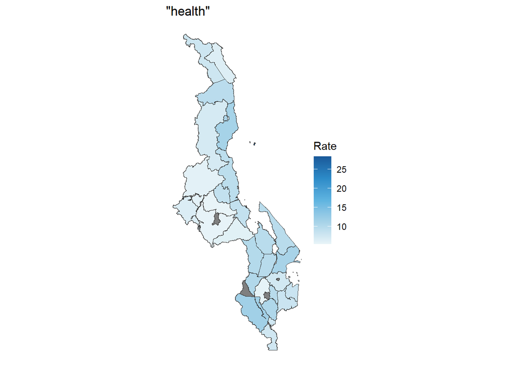

Figure 28: Three palettes applied to the same incidence rate data. The palette choice substantially changes the visual impression.

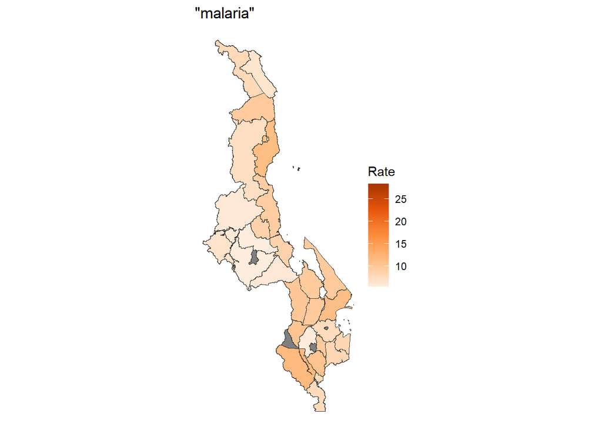

Figure 29: Three palettes applied to the same incidence rate data. The palette choice substantially changes the visual impression.

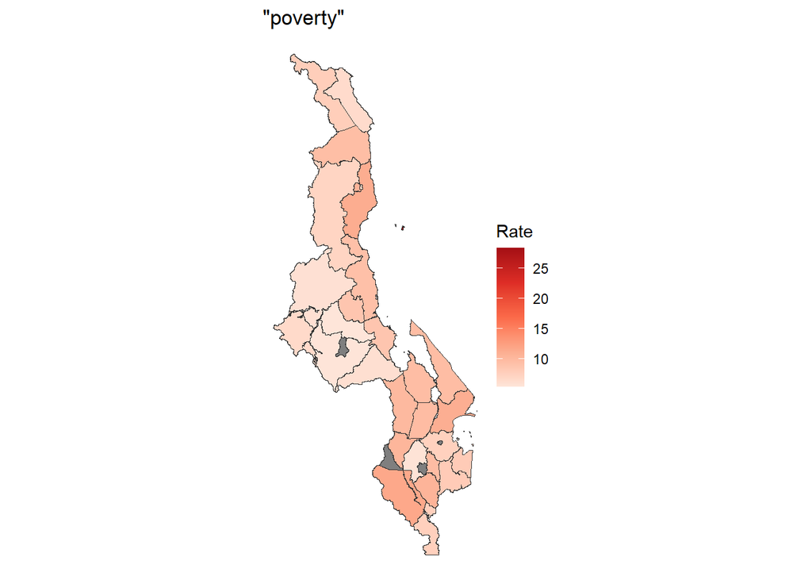

Figure 30: Three palettes applied to the same incidence rate data. The palette choice substantially changes the visual impression.

```r
joined <- mw_join(health_data, quiet = TRUE)

mw_map(data = joined, fill = "rate_per_1000") +
  scale_fill_mw("health", name = "Rate") +
  labs(title = '"health"')

mw_map(data = joined, fill = "rate_per_1000") +
  scale_fill_mw("malaria", name = "Rate") +
  labs(title = '"malaria"')

mw_map(data = joined, fill = "rate_per_1000") +
  scale_fill_mw("poverty", name = "Rate") +
  labs(title = '"poverty"')
```

### 5.2.1 Reversing a palette

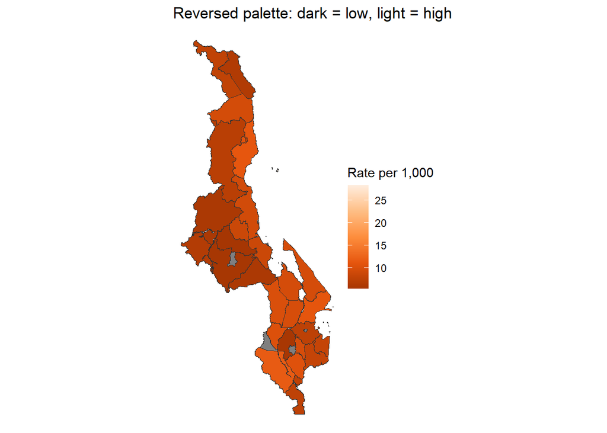

Figure 31: The malaria palette reversed. Now lighter colour = higher value.

```r
mw_map(data = joined, fill = "rate_per_1000") +
  scale_fill_mw("malaria", reverse = TRUE, name = "Rate per 1,000") +
  labs(title = "Reversed palette: dark = low, light = high")
```

### 5.2.2 Extracting hex codes with `get_mw_palette()`

You can extract the raw hex codes from any palette for use outside of ggplot2 — in tables, slide decks, custom charts, or base R plots. The `n` argument interpolates the palette to exactly `n` colours, which is useful when you need more or fewer colours than the palette’s default length.

```r
# All colours in the three-colour 'regions' palette
get_mw_palette("regions")
```

[output not shown]

```r
# Interpolate to exactly 7 colours from the 'health' palette
get_mw_palette("health", n = 7)
```

```
#> [1] "#E8F4F8" "#BCDEED" "#8EC8E5" "#5EB4E0" "#3C98D0" "#267AB8" "#1A5A9A"
```

```r
# Reverse the malaria palette
get_mw_palette("malaria", reverse = TRUE)
```

```
#> [1] "#A63603" "#E6550D" "#FD8D3C" "#FDBE85" "#FEEDDE"
```

# 6 Layout and Styling

A publication-ready map needs more than data and colour. It needs a descriptive title, an informative subtitle, a source citation in the caption, and a well-placed legend. `mw_layout()` is a convenience function that applies all of these in a single call with consistent typographic styling throughout.

`mw_layout()` returns a special `mw_layout` class object. When you add it to a ggplot2 map using `+`, it applies both a `labs()` call (for the text elements) and a `theme()` call (for the visual formatting) — so you get both content and styling in one step.

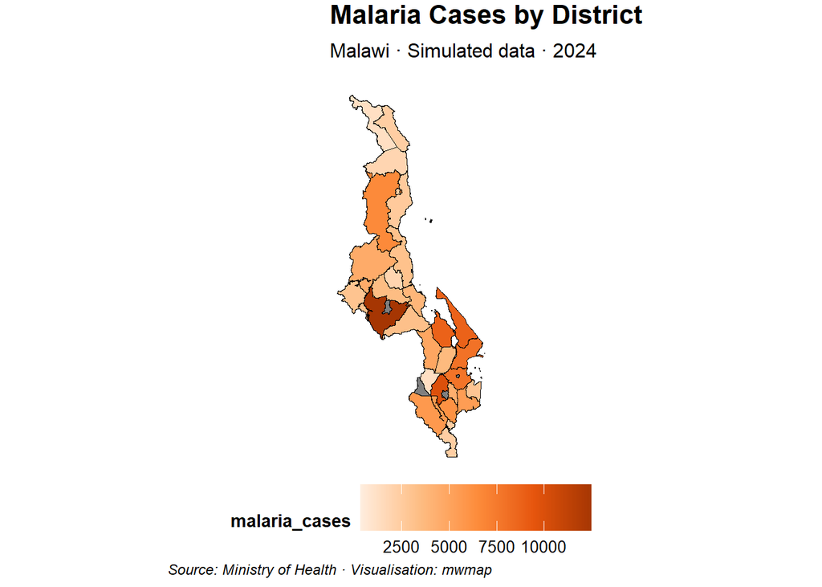

Figure 32: The same choropleth polished with mw_layout() for titles, legend placement, and typography.

```r
mw_choropleth(health_data, malaria_cases, palette = "malaria", quiet = TRUE) +
  mw_layout(
    title = "Malaria Cases by District",
    subtitle = "Malawi · Simulated data · 2024",
    caption = "Source: Ministry of Health · Visualisation: mwmap",
    legend_position = "bottom",
    legend_direction = "horizontal",
    legend_title = "Reported Cases"
  )
```

The most useful `mw_layout()` arguments:

`mw_layout()` arguments

| Argument | Description |
| --- | --- |
| `title`, `subtitle`, `caption` | The three standard ggplot2 text elements |
| `legend_position` | `"right"`, `"left"`, `"bottom"`, `"top"`, or `"none"` |
| `legend_direction` | `"vertical"` (default) or `"horizontal"` — horizontal suits a bottom legend |
| `theme` | Base ggplot2 theme: `"void"` (no axes, default), `"minimal"`, or `"classic"` |
| `panel_border` | `TRUE` adds a thin rectangle around the map panel |
| `background_color` | Plot background fill. Default: `"white"` |
| `grid_major` | `TRUE` adds lat/lon grid lines |
| `font_family` | Font family for all text |
| `title_size` | Title font size. Default: 16 |
| `caption_size` | Caption font size. Default: 9 |
| `legend_key_size` | Size of each legend key in cm |

**TipLegend position for published figures**

For figures intended for journal publication or formal reports, `legend_position = "right"` (the default) is usually the best choice — it does not compress the map vertically. For slide decks or dashboards where space is at a premium, `"bottom"` with `legend_direction = "horizontal"` often works better.